# Water Date Preparation for CDC Data call Spring 2023

# Start

`['PWSIDNumber', 'Year', 'AnalyteName', 'AnalyteCode', 'ConcentrationUnits', 'Concentration', 'DateSampled', 'SamplePointID', 'DetectionLimit', 'DetectionLimitUom', 'NonDetectFlag']`

It contains sampling results from 2012 to 2021 as below:

| Year | Rows of data |
| --- | --- |
| 2012 | 9069 |
| 2018 | 7491 |
| 2015 | 7140 |
| 2013 | 6970 |
| 2016 | 6460 |
| 2021 | 6444 |
| 2019 | 6396 |
| 2017 | 6292 |
| 2020 | 5972 |
| 2014 | 5869 |

- **Step 1-** Adjusting AnalyteCode following the instructions all code values of 1038 were changed into 1040 (21,928 rows). Also all data for Analytedoe 1041 removed, since not required by data call (17 rows).
- **Step 2 -** Initial validation test An initial validation against Data Dictionary rules done on columns that will be present in the final summary file. all passed validation for the following columns: ‘RowIdentifier’, ‘PWSIDNumber’, ‘Year’, ‘AnalyteCode’, ‘ConcentrationUnits’, ‘Concentration’, ‘DateSampled’]

After these intial steps number of data points bsed on each AnalyteCode are as below:

| AnalyteCode | No. Rows |
| --- | --- |
| 1040 | 21945 |
| 2050 | 7684 |
| 2039 | 7684 |
| 2987 | 6518 |
| 2984 | 6518 |
| 1005 | 6268 |
| 2950 | 3457 |
| 2456 | 3416 |
| 4010 | 3093 |
| 4006 | 1503 |

- **Step 3 -** Checked if the ConcentrationUnits for each AnalyteCode applies with the values in the Data Dictionary
- **Step 4 -** Checked if uranium needs a change of ConcentrationUnits from pci/l to ug/l
- **Step 4 -** Checking rows with NonDetectFlag. Below is the result for checking rows with a NonDetectionFlag = 1. Most of them have a half LDL value for their concentrations (refer to HTG Guide), and 74 have no value for Concentration LDL.

| is_half_LDL | number |
| --- | --- |
| 0.5 | 31886 |
| NaN | 74 |

We checked for the applied LDL and since some of them do not match to the values in HTG, we cahnged all the concentrations for these rows (31,886) into 0, so in the next step will be checked and changed into appropriate half LDL as suggested by HTG 2023.

- **Step 5 -** Followed Appendix G of HTG 2023, checked the Concentration values against thir Lowest Detection Limit (LDL) and replaced with the suggested values where lower

```
[1] "number of revised below LDL value: 32180"
```

- **Step 5 -** Averaged duplicates into one values. Checked for duplicated of same analyte sampled in the same day from same point location, and averaged them into one value. It contained repeatitions for values in columns (PWSIDNumber, Year, AnalyteCode, DateSampled, SamplePointID). Added a new column “NumSamples” that can account for these number of samples. (The highest was 28 for one analyte sampling in the same point in the same date)

```
[1] "initial rows in data:  68086"
[1] "no. of rows after averaging same day/point/analyte:  64144"
```

before starting the summarization, we took a look into maximum concentration value for each analyte compared to its median over all dataset (from 2012 to 2021)

| AnalyteCode | maximum | median | DateSampled |
| --- | --- | --- | --- |
| 1005 | 29.20 | 4.53000 | 2013-04-15 |
| 1040 | 34.30 | 3.76000 | 2016-12-13 |
| 2039 | 109.00 | 0.23000 | 2014-10-10 |
| 2050 | 1.44 | 0.00200 | 2014-05-21 |
| 2050 | 1.44 | 0.00200 | 2014-05-21 |
| 2456 | 83.60 | 9.98625 | 2015-07-14 |
| 2950 | 151.00 | 31.62500 | 2016-07-11 |
| 2984 | 2.02 | 0.00100 | 2020-04-28 |
| 2984 | 2.02 | 0.00100 | 2020-04-28 |
| 2987 | 10.50 | 0.00500 | 2014-10-07 |

[output cut: 5 more lines]

===> The maximum value for analyte 2039 (DEHP) seems too large compared to its median. May be good to double-check. last column above shows the sampling date for the maximum value. Below, we have also provided plots for the distributions:

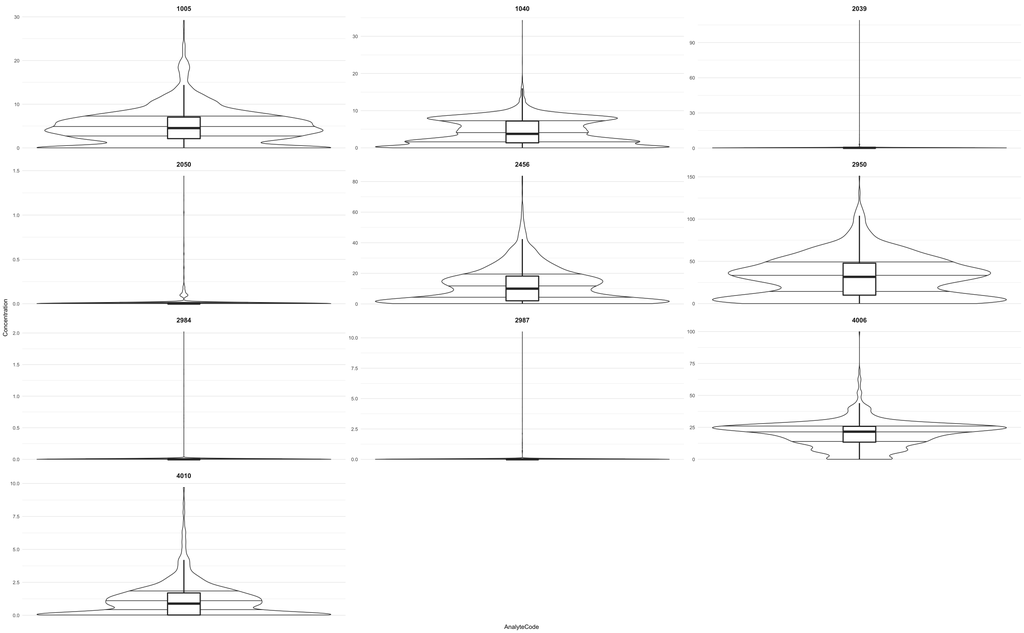

## Starting the Summarization

- **Step S.1 -** Summarized annual means for the 8 anlytes following HTG 2023:

| Year | NuLocations | NuSamples | Analytes | Non_detects |
| --- | --- | --- | --- | --- |
| 2012 | 5496 | 8490 | 8 | 4136 |
| 2013 | 4596 | 6370 | 8 | 3344 |
| 2014 | 3895 | 5245 | 8 | 2692 |
| 2015 | 4516 | 6319 | 8 | 3667 |
| 2016 | 4463 | 5664 | 8 | 3102 |
| 2017 | 4134 | 5592 | 8 | 2820 |
| 2018 | 4962 | 6808 | 8 | 3597 |
| 2019 | 4282 | 5662 | 8 | 2885 |
| 2020 | 3887 | 5276 | 8 | 2536 |
| 2021 | 4349 | 5787 | 8 | 3024 |

- **Step S.2 -** Summarized annual means for the two Disinfection By-products following HTG 2023:

..

| Year | NuLocations | NuSamples | Analytes | Non_detects |
| --- | --- | --- | --- | --- |
| 2012 | 244 | 579 | 2 | 32 |
| 2013 | 306 | 598 | 2 | 45 |
| 2014 | 282 | 623 | 2 | 18 |
| 2015 | 384 | 820 | 2 | 55 |
| 2016 | 408 | 796 | 2 | 62 |
| 2017 | 368 | 700 | 2 | 44 |
| 2018 | 376 | 682 | 2 | 24 |
| 2019 | 445 | 734 | 2 | 49 |
| 2020 | 398 | 687 | 2 | 22 |
| 2021 | 374 | 654 | 2 | 26 |

- **Step S.3 -** Summarized annual maximums for all the analytes following HTG 2023:

…

| Year | NuLocations | NuSamples | Analytes | Non_detects |
| --- | --- | --- | --- | --- |
| 2012 | 5615 | 9069 | 10 | 4168 |
| 2013 | 4771 | 6968 | 10 | 3389 |
| 2014 | 4022 | 5868 | 10 | 2710 |
| 2015 | 4719 | 7139 | 10 | 3722 |
| 2016 | 4716 | 6460 | 10 | 3164 |
| 2017 | 4336 | 6292 | 10 | 2864 |
| 2018 | 5170 | 7490 | 10 | 3621 |
| 2019 | 4558 | 6396 | 10 | 2934 |
| 2020 | 4103 | 5963 | 10 | 2558 |
| 2021 | 4561 | 6441 | 10 | 3050 |

- **Step S.4 -** Summarized quarterly means for all the analytes following HTG 2023: We first separatd the four analytes for which the quarterly values are required. Nitrate and Atrazine and disinfection-by-products (TTHM and HAA5). Then for each group, since the methods are different and similar to their annual averages, we calculated the average quarterly values

… * **Step S.4.1 -** For Atrazine and Nitrate

…

| SummaryTimePeriod | NuLocations | NuSamples | Analytes | Non_detects |
| --- | --- | --- | --- | --- |
| 2012-1 | 978 | 989 | 2 | 312 |
| 2012-2 | 1202 | 1206 | 2 | 426 |
| 2012-3 | 1035 | 1050 | 2 | 390 |
| 2012-4 | 708 | 715 | 2 | 137 |
| 2013-1 | 999 | 1007 | 2 | 265 |
| 2013-2 | 862 | 874 | 2 | 250 |
| 2013-3 | 709 | 717 | 2 | 226 |
| 2013-4 | 670 | 677 | 2 | 211 |
| 2014-1 | 792 | 801 | 2 | 159 |
| 2014-2 | 682 | 691 | 2 | 167 |

[output cut: 30 more lines]

Here we only provided the first 10 rows of total 40.

- **Step S.4.1 -** For disinfection by-products

….

| SummaryTimePeriod | NuLocations | NuSamples | Analytes | Non_detects |
| --- | --- | --- | --- | --- |
| 2012-1 | 39 | 96 | 2 | 4 |
| 2012-2 | 45 | 137 | 2 | 3 |
| 2012-3 | 119 | 242 | 2 | 24 |
| 2012-4 | 41 | 104 | 2 | 1 |
| 2013-1 | 53 | 114 | 2 | 7 |
| 2013-2 | 43 | 106 | 2 | 2 |
| 2013-3 | 165 | 274 | 2 | 34 |
| 2013-4 | 45 | 104 | 2 | 2 |
| 2014-1 | 50 | 112 | 2 | 3 |
| 2014-2 | 57 | 122 | 2 | 3 |

[output cut: 30 more lines]

Here we only provided the first 10 rows of total 40.

- **Step F -** Then the all resulted 5 tables were aggreagated into one table in conformance with HTG and Data Dictionary 2023

As the final step, we checked the data against the 8 steps in the Gateway 2022 (Appendix F of HTG)